# Praca domowa 2

Mateusz Lambert

## Dane

Dane wykorzystane w Pracy domowej 2 są związane z kampaniami marketingu bezpośredniego portugalskiej instytucji bankowej. Kampanie marketingowe opierały się na rozmowach telefonicznych. Często wymagany był więcej niż jeden kontakt z tym samym klientem, aby uzyskać dostęp do tego, czy produkt (lokata bankowa) zostanie (lub nie) subskrybowany. Opis wszystkich kolumn znajduje się również w pliku `README.md`.

#### Dane klienta banku

| Zmienna | Opis |
| --- | --- |
| **age** | wiek |
| **job** : admin., unknown, unemployed, management, housemaid, entrepreneur, student, blue-collar, self-employed, retired, technician, services | administrator, nieznany, bezrobotny, kierownictwo, pokojówka, przedsiębiorca, student, pracownik fizyczny, samozatrudniony, emeryt, technik, usługi |
| **marital** : married, divorced, single; note: divorced means divorced or widowed) | żonaty/zamężna, rozwiedzion_, kawaler/panna; uwaga: rozwiedzion_ oznacza rozwiedzion_ lub owdowiał_ |
| **education** : unknown, secondary, primary, tertiary | nieznane, średnie, podstawowe, wyższe |
| **default** : yes, no | czy kredyt jest niespłacany : tak, nie |
| **balance** : average yearly balance, in euros | średnie roczne saldo w euro |
| **housing** : has housing loan? yes, no | czy posiada kredyt mieszkaniowy? tak, nie |
| **loan** : has personal loan? yes, no | ma pożyczkę osobistą? tak, nie |

#### Dane związane z ostatnim kontaktem w bieżącej kampanii

| Zmienna | Opis |
| --- | --- |
| **contact** : unknown, telephone, cellular | nieznany, telefon, komórkowy |
| **day** : last contact day of the month | dzień miesiąca ostatniego kontaktu |
| **month** : last contact month of year, jan, feb, mar, …, nov, dec | miesiąc ostatniego kontaktu w roku, styczeń, luty, marzec, …, listopad, grudzień |
| **duration** : last contact duration, in seconds | czas trwania ostatniego kontaktu w sekundach |

## Zadanie 1

Weźmy pod uwagę zawody (`job`) klientów banku. Który zawód zacząco wyróżnia się w posiadaniu kredytu mieszkaniowego lub pożyczki osobistej?

[figure not shown]

```r
z1 <- df %>%
  group_by(job) %>%
  summarise(
    housing_yes = sum(housing=="yes", na.rm=T),
    housing_no = sum(housing=="no", na.rm=T),
    loan_yes = sum(loan=="yes", na.rm=T),
    loan_yes = sum(loan=="no", na.rm=T),
    total = n()
  ) %>%
  mutate(
    p_housing = housing_yes / total,
    p_loan = loan_yes / total
  )

z_long <- z1 %>%
  select(job, p_housing, p_loan) %>%
  pivot_longer(
    cols      = c(p_housing, p_loan),
    names_to = "type",
    values_to = "proportion"
  )

ggplot(z_long, aes(x = reorder(job, proportion), y = proportion)) +
  geom_col() +
  coord_flip() +
  facet_wrap(~ type, ncol = 2, scales = "free_y",
             labeller = as_labeller(c(
               p_housing = "Kredyt mieszkaniowy",
               p_loan = "Pożyczka osobista"
             ))) +
  scale_x_discrete(labels = function(x) x) +
  labs(
    title = "Proporcje posiadaczy kredytu mieszkaniowego i pożyczki wg zawodu",
    x = "Zawód",
    y = "Proporcja"
  ) +
  theme(strip.text = element_text(face = "bold"))
```

**Komentarz:**

Żeby prościej było przeanalizować dane, to rozważyłem dla każdego zawodu procent osób z kredytami. Początkowo chciałem oba wykresy umieścić na jednym rysunku ale wydaje mi się, że tak jest bardziej czytelnie. Widzimy, że w kategorii kredytu mieszkaniowego wyróżniają się zawody ‘blue-collar’, ‘services’, ‘unknown’ i ‘retired’, przy czym pierwsze dwa wykazują dużą liczbę kredytów u pracowników, a ostatnie dwa małą liczbę.

## Zadanie 2

Wybierając klientów, którzy mają nieznany sposób kontaktu (`contact`). Jak rozkłada się ich wiek w podziale na status związku?

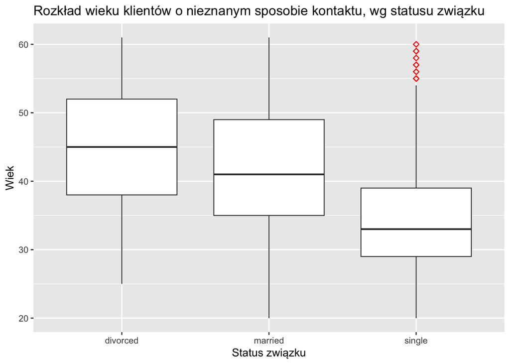

```r
z2 <- df %>%
  filter(contact=="unknown")

ggplot(z2, aes(x = marital, y = age)) +
  geom_boxplot(
    outlier.shape = 5,
    outlier.fill = "white",
    outlier.color = "red",
    size = 0.4
  ) +
  labs(
    title = "Rozkład wieku klientów o nieznanym sposobie kontaktu, wg statusu związku",
    x = "Status związku",
    y = "Wiek"
  )
```

**Komentarz:**

Możemy zobaczyć, że osoby o statusie ‘single’ są wyraźnie młodsze od pozostałych grup. Mediana wieku w tej grupie to około 32 lat. Na wykresie widoczne są też outliery, pokazujące, że bardzo mała grupa osób starszych jest ‘single’.

Grupa ‘married’ prezentuje ‘szerszy’ rozkład. Mediana wieku w tej grupie to około 41 lat, więc jest ona większa niż w poprzedniej grupie, ale niższa niż w kolejnej. Większość obserwacji mieści się w przedziale (35, 49) lat.

Z kolei w grupie ‘divorced’ możemy zauważyć brak osób młodych (poniżej 25 roku życia), a środek cieżkości jest nieco przesunięty w górę względem grupy ‘married’. Mediana wieku w tej grupie to 45 lat.

## Zadanie 3

Jaka jest różnica pomiędzy średnim rocznym saldem w euro w zależności od wykształcenia i tego czy kredyt jest niespłacany?

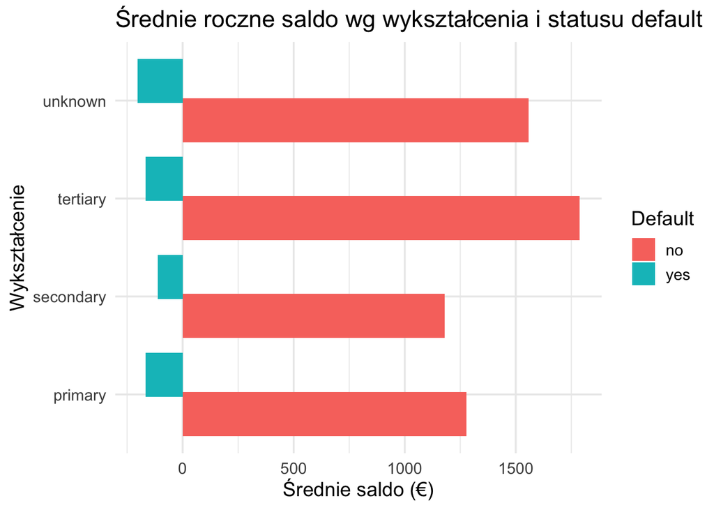

```r
z3 <- df %>%
  group_by(education, default) %>%
  summarise(
    mean_b = mean(balance, na.rm = T),
    .groups = "drop"
  )

ggplot(z3, aes(x = education, y = mean_b, fill = default)) +
  geom_col(position = position_dodge(width = 0.8)) +
  labs(
    title = "Średnie roczne saldo wg wykształcenia i statusu default",
    x = "Wykształcenie",
    y = "Średnie saldo (€)",
    fill  = "Default"
  ) +
  coord_flip() +
  theme_minimal(base_size = 14)
```

**Komentarz:**

Przede wszystkim możemy zauważyć, że niezależnie od wykształcenia, dla osób niespłacających kredytu średnie saldo jest ujemne. Ponadto widzimy też, że wśród osób spłacających kredyt największy średni balans mają osoby z najwyższym wykształceniem. Drugi najwyższy średni balans jest dla grupy o nieznanym wykształceniu, a najniższy dla osób z wykształceniem średnim. Natomiast osoby o średnim wykształceniu mają niższe długi w przypadku niepłacenia kredytu.

## Zadanie 4

Czy dzień i miesiąc kontaktu z klientem ma wpływ na średni czas trwania rozmowy w stosunku do średniego czasu trwania rozmowy?

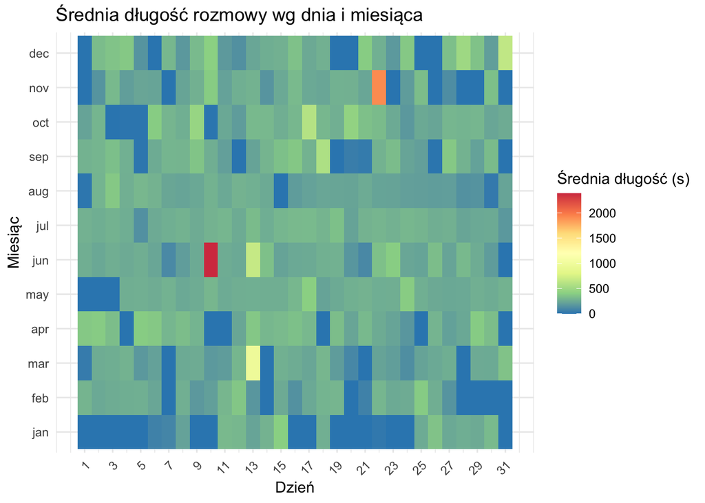

```r
months <- factor(tolower(month.abb), levels = tolower(month.abb))

z4 <- merge(
  expand.grid(month = months, day = 1:31),
  df %>% mutate(month = tolower(month)) %>%
       group_by(month, day) %>%
       summarise(mean_duration = mean(duration, na.rm = T), .groups="drop"),
  by = c("month","day"), all.x = T
) %>%
  replace_na(list(mean_duration = 0))

ggplot(z4, aes(day, month, fill = mean_duration)) +
  geom_tile() +
  scale_fill_distiller(name = "Średnia długość (s)", palette = "Spectral") +
  scale_x_continuous(breaks = seq(1,31,2)) +
  labs(title="Średnia długość rozmowy wg dnia i miesiąca", x="Dzień", y="Miesiąc") +
  theme_minimal() +
  theme(axis.text.x = element_text(angle=45, hjust=1))
```

## Zadanie 5

Czy jest zależnośc pomiędzy wiekiem klientów a ich średnim rocznym saldzie w euro w podziale na stopień wykształcenia?

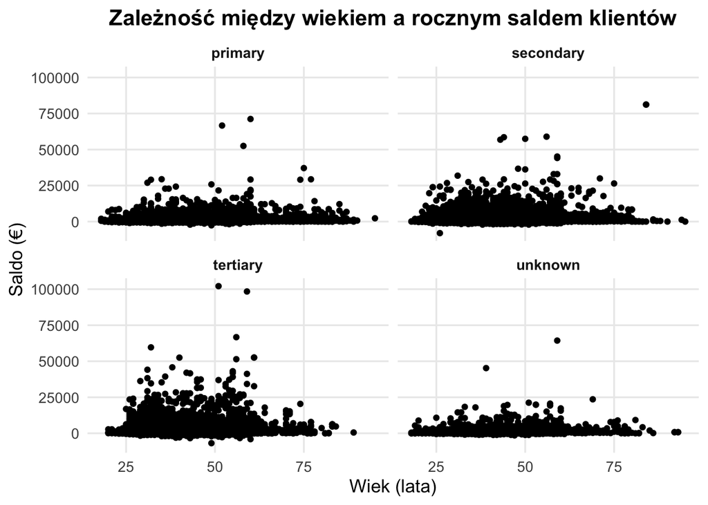

```r
ggplot(df, aes(x = age, y = balance)) +
  geom_point() +
  facet_wrap(~ education) +
  labs(
    title = "Zależność między wiekiem a rocznym saldem klientów",
    x = "Wiek (lata)",
    y = "Saldo (€)"
  ) +
  theme_minimal(base_size = 13) +
  theme(
    strip.text = element_text(face = "bold"),
    plot.title = element_text(face = "bold", hjust = 0.5),
    plot.subtitle = element_text(size = 11, hjust = 0.5),
    panel.grid.minor = element_blank()
  )
```

**Komentarz:**

Największe salda pojawiają się w grupie ‘tertiary’ i posiadają je osoby w przedziale wieku od około 30 do 60 lat. Poza tym przedziałem salda są znacznie niższe. Podobnie sytuacja wygląda w grupie ‘secondary’. W porównaniu do poprzedniej grupy, osoby poniżej 25 r.ż mają wyższe salda, ale w ogólności osoby z tej grupy mają niższe salda niż ‘tertiary’. W pozostałych dwóch grupach salda są rozłożone w miarę równomiernie (niezależnie od wieku), jednak są one zdecydowanie niższe niż w poprzednich grupach (z wyjątkiem pojedynczych przypadków).

## Zadanie 6

Rozważmy osoby, które są bezrobotne albo ich zawód jest nieznany. Czy procent osób, które są bezrobotne i nie spłacają kredytu jest większy od procenta osób o nieznanym zawodzie i nie spłacanym kredycie? Jaki typ kredytu jest (przez te osoby) najczęściej niespłacany?

```r
z6 <- df %>%
  filter(job %in% c("unemployed", "unknown")) %>%
  filter(housing == "yes" | loan == "yes") %>%
  group_by(job) %>%
  summarise(
    total_credit = n(),
    defaults  = sum(default == "yes", na.rm = T),
    p_defaults = defaults / total_credit * 100,
    housing_defaults = sum(default == "yes" & housing == "yes", na.rm = T),
    loan_defaults = sum(default == "yes" & loan == "yes", na.rm = T),
    .groups = "drop"
  )

knitr::kable(
  z6,
  caption = "Procent niespłacających kredytu u osób bezrobotnych i o nieznanym zawodzie",
)
```

Procent niespłacających kredytu u osób bezrobotnych i o nieznanym zawodzie

| job | total_credit | defaults | p_defaults | housing_defaults | loan_defaults |
| --- | --- | --- | --- | --- | --- |
| unemployed | 589 | 22 | 3.735144 | 20 | 7 |
| unknown | 28 | 1 | 3.571429 | 1 | 0 |

**Komentarz:**

Trochę nie byłem pewien jak to interpretować z uwagi na to, że w danych są rekordy, w których nie ma żadnego kredytu ale mimo to jest default (???niespłacanie nieistniejącego kredytu???). Zatem po prostu rozważyłem te dane, w których jest jakiś kredyt do niespłacania. Z tabelki możemy odczytać, że większy procent bezrobotnych posiadających kredyt go nie spłaca. A najczęściej niespłacany kredyt w tych grupach to housing.